# CyTOF data analysis workflow for differential discovery with `CATALYST`

Author

written by Helena L. Crowell (given by Mark Robinson)

Published

November 26, 2023

# Preamble

## Resources

- `CATALYST` package [vignette](http://bioconductor.org/packages/release/bioc/vignettes/CATALYST/inst/doc/differential.html) on differential discovery
- article Nowicka et al. (2019) with more detailed explanations

## Dependencies

```r
# load required packages
library(CATALYST) # clustering, visualization
library(diffcyt)  # differential analysis
```

# Example data

```r
# load example data
data(PBMC_fs, PBMC_panel, PBMC_md)
PBMC_fs
```

```
A flowSet with 8 experiments.

column names(24): CD3(110:114)Dd CD45(In115)Dd ... HLA-DR(Yb174)Dd
  CD7(Yb176)Dd
```

```r
PBMC_panel
```

```
       fcs_colname antigen marker_class
1   CD3(110:114)Dd     CD3         type
2    CD45(In115)Dd    CD45         type
3   pNFkB(Nd142)Dd   pNFkB        state
4    pp38(Nd144)Dd    pp38        state
5     CD4(Nd145)Dd     CD4         type
6    CD20(Sm147)Dd    CD20         type
7    CD33(Nd148)Dd    CD33         type
8  pStat5(Nd150)Dd  pStat5        state
9   CD123(Eu151)Dd   CD123         type
10   pAkt(Sm152)Dd    pAkt        state
11 pStat1(Eu153)Dd  pStat1        state
12  pSHP2(Sm154)Dd   pSHP2        state
13 pZap70(Gd156)Dd  pZap70        state
14 pStat3(Gd158)Dd  pStat3        state
15   CD14(Gd160)Dd    CD14         type
16 pSlp76(Dy164)Dd  pSlp76        state
17   pBtk(Er166)Dd    pBtk        state
18 pPlcg2(Er167)Dd  pPlcg2        state
19   pErk(Er168)Dd    pErk        state
20   pLat(Er170)Dd    pLat        state
21    IgM(Yb171)Dd     IgM         type
22    pS6(Yb172)Dd     pS6        state
23 HLA-DR(Yb174)Dd  HLA-DR         type
24    CD7(Yb176)Dd     CD7         type
```

```r
table(PBMC_panel$marker_class)
```

```
state  type
   14    10
```

```r
PBMC_md
```

```
                file_name sample_id condition patient_id
1 PBMC_patient1_BCRXL.fcs    BCRXL1     BCRXL   Patient1
2   PBMC_patient1_Ref.fcs      Ref1       Ref   Patient1
3 PBMC_patient2_BCRXL.fcs    BCRXL2     BCRXL   Patient2
4   PBMC_patient2_Ref.fcs      Ref2       Ref   Patient2
5 PBMC_patient3_BCRXL.fcs    BCRXL3     BCRXL   Patient3
6   PBMC_patient3_Ref.fcs      Ref3       Ref   Patient3
7 PBMC_patient4_BCRXL.fcs    BCRXL4     BCRXL   Patient4
8   PBMC_patient4_Ref.fcs      Ref4       Ref   Patient4
```

```r
PBMC_fs[[1]]
```

```
flowFrame object 'PBMC_patient1_BCRXL.fcs'
with 528 cells and 24 observables:
                name   desc     range  minRange  maxRange
$P1   CD3(110:114)Dd    CD3   229.283 -11.48920   229.283
$P2   CD45(In115)Dd    CD45  1901.156   6.28953  1901.156
$P3   pNFkB(Nd142)Dd  pNFkB   364.373  -8.70884   364.373
$P4   pp38(Nd144)Dd    pp38    95.834 -10.81737    95.834
$P5   CD4(Nd145)Dd      CD4   399.547  -8.83552   399.547
...              ...    ...       ...       ...       ...
$P20 pLat(Er170)Dd     pLat   899.402  -3.91856   899.402
$P21 IgM(Yb171)Dd       IgM   245.025  -2.83519   245.025
$P22 pS6(Yb172)Dd       pS6   909.123  -4.35815   909.123
$P23 HLA-DR(Yb174)Dd HLA-DR   465.949  -5.64699   465.949
$P24 CD7(Yb176)Dd       CD7  1013.611  -2.32894  1013.611
3 keywords are stored in the 'description' slot
```

```r
y <- exprs(PBMC_fs[[1]])
dim(y)
```

```
[1] 528  24
```

## Data preparation

Data used and returned throughout differential analysis are held in objects of the *SingleCellExperiment* class. To bring the data into the appropriate format, `prepData()` requires the following inputs:

- `x`: a `flowSet` holding the raw measurement data, or a character string that specifies a path to a set of FCS files.
- `panel`: a 2 column data.frame that contains for each marker of interest i) its column name in the raw input data, and ii) its targeted protein marker.
- `md`: a `data.frame` with columns describing the experimental design.

```r
(sce <- prepData(PBMC_fs, PBMC_panel, PBMC_md))
```

```
class: SingleCellExperiment
dim: 24 5428
metadata(2): experiment_info chs_by_fcs
assays(2): counts exprs
rownames(24): CD3 CD45 ... HLA-DR CD7
rowData names(3): channel_name marker_name marker_class
colnames: NULL
colData names(3): sample_id condition patient_id
reducedDimNames(0):
mainExpName: NULL
altExpNames(0):
```

# Clustering

## `cluster`: *FlowSOM* clustering & *ConsensusClusterPlus* metaclustering

```r
sce <- cluster(sce,
    features = "type",
    xdim = 10, ydim = 10,
    maxK = 20, seed = 1)
colData(sce)
```

```
DataFrame with 5428 rows and 4 columns
     sample_id condition patient_id cluster_id
      <factor>  <factor>   <factor>   <factor>
1       BCRXL1     BCRXL   Patient1         56
2       BCRXL1     BCRXL   Patient1         40
3       BCRXL1     BCRXL   Patient1         1
4       BCRXL1     BCRXL   Patient1         46
5       BCRXL1     BCRXL   Patient1         95
...        ...       ...        ...        ...
5424      Ref4       Ref   Patient4         71
5425      Ref4       Ref   Patient4         16
5426      Ref4       Ref   Patient4         73
5427      Ref4       Ref   Patient4         90
5428      Ref4       Ref   Patient4         32
```

```r
rowData(sce)
```

```
DataFrame with 24 rows and 4 columns
          channel_name marker_name marker_class used_for_clustering
           <character> <character>     <factor>           <logical>
CD3     CD3(110:114)Dd         CD3        type                 TRUE
CD45     CD45(In115)Dd        CD45        type                 TRUE
pNFkB   pNFkB(Nd142)Dd       pNFkB        state               FALSE
pp38     pp38(Nd144)Dd        pp38        state               FALSE
CD4       CD4(Nd145)Dd         CD4        type                 TRUE
...                ...         ...          ...                 ...
pLat     pLat(Er170)Dd        pLat        state               FALSE
IgM       IgM(Yb171)Dd         IgM        type                 TRUE
pS6       pS6(Yb172)Dd         pS6        state               FALSE
HLA-DR HLA-DR(Yb174)Dd      HLA-DR        type                 TRUE
CD7       CD7(Yb176)Dd         CD7        type                 TRUE
```

```r
cc <- cluster_codes(sce)
names(cc)
```

```
 [1] "som100" "meta2"  "meta3"  "meta4"  "meta5"  "meta6"  "meta7"  "meta8"
 [9] "meta9"  "meta10" "meta11" "meta12" "meta13" "meta14" "meta15" "meta16"
[17] "meta17" "meta18" "meta19" "meta20"
```

```r
cc[1:5, 1:5]
```

```
  som100 meta2 meta3 meta4 meta5
1      1     1     1     1     1
2      2     1     1     1     1
3      3     2     2     2     2
4      4     2     2     2     2
5      5     2     2     2     2
```

Let K = `xdim` x `ydim` be the number of *FlowSOM* clusters. `cluster` will add information to the following slots of the input `SingleCellExperiment`:

## Delta area plot

The delta area represents the amount of extra cluster stability gained when clustering into k groups as compared to k-1 groups. It can be expected that high stability of clusters can be reached when clustering into the number of groups that best fits the data. The “natural” number of clusters present in the data should thus corresponds to the value of k where there is no longer a considerable increase in stability (plateau onset). For more details, the user can refer to the original description of the consensus clustering method (Monti et al. 2003).

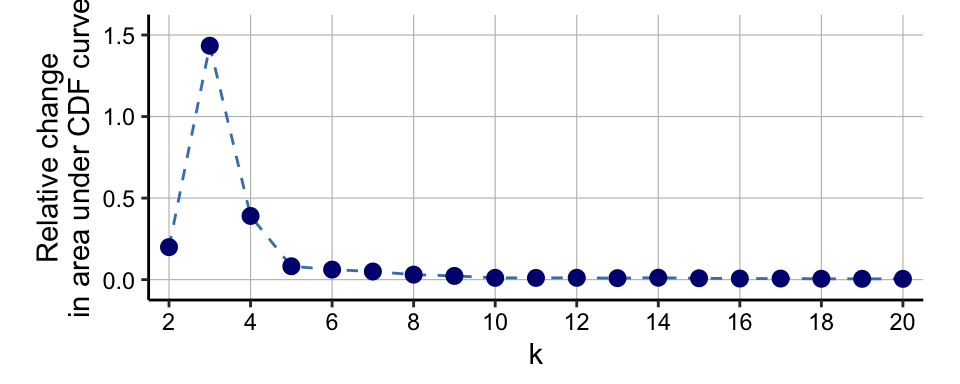

```r
# access & render delta area plot
# (equivalent to metadata(sce)$delta_area)
delta_area(sce)
```

# Visualization

## `plotCounts`: Number of cells measured per sample

The number of cells measured per sample may be plotted with `plotCounts`. This plot should be used as a guide together with other readouts to identify samples where not enough cells were assayed. Here, the grouping of samples (x-axis) is controlled by `group_by`; bars can be colored by a an additional cell metadata variable (argument `color_by`):

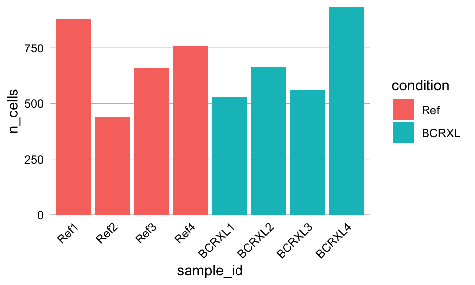

```r
plotCounts(sce,
    group_by = "sample_id",
    color_by = "condition")
```

## `pbMDS`: Pseudobulk-level MDS plot

A multi-dimensional scaling (MDS) plot on aggregated measurement values may be rendered with `pbMDS`. Such a plot will give a sense of similarities between cluster and/or samples in an unsupervised way and of key difference in expression before conducting any formal testing.

Arguments `color_by`, `label_by`, `shape_by` can be used to color, label, shape pseudobulk instances by cell metadata variables of interest. Moreover, `size_by = TRUE` will scale point sizes proportional to the number of cells that went into aggregation. Finally, a custom color palette may be supplied to argument `pal.`

### MDS on sample-level pseudobulks

A multi-dimensional scaling (MDS) plot on median marker expression by sample has the potential to reveal global proteomic differences across conditions or other experimental metadata. Here, we color points by condition (to reveal treatment effects) and further shape them by patient (to highlight patient effects). In our example, we can see a clear horizontal (MDS dim. 1) separation between reference (REF) and stimulation condition (BCRXL), while patients are, to a lesser extent, separated vertically (MDS dim. 2):

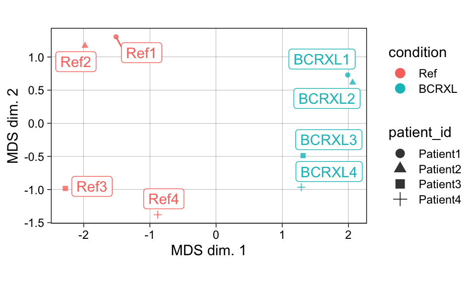

```r
pbMDS(sce, shape_by = "patient_id")
```

## `plotExprHeatmap`: Heatmap of aggregated marker expressions

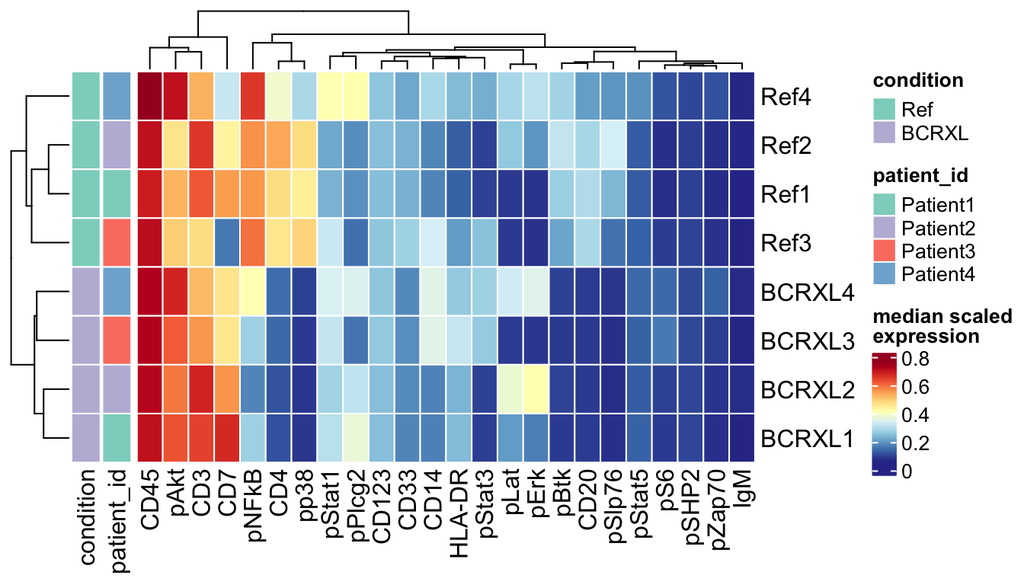

```r
plotExprHeatmap(sce)
```

When `by != "sample_id"`, the clustering to use for aggregation is specified via `k`:

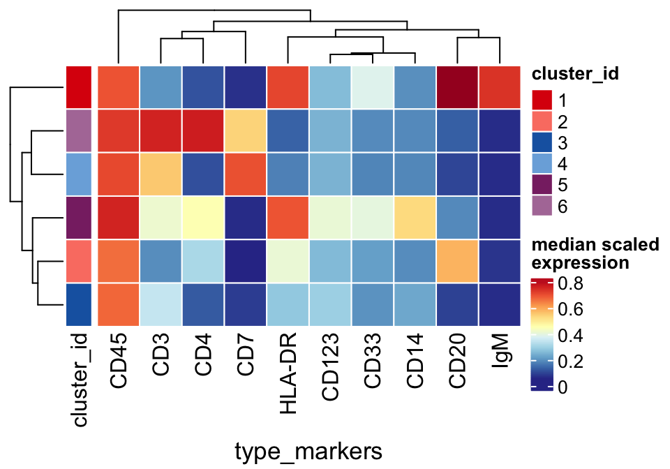

```r
plotExprHeatmap(sce,
    features = "type",
    by = "cluster_id",
    k = "meta6")
```

# Dimensionality reduction

The number of cells in cytometry data is typically large, and for visualization of cells in a two-dimensional space it is often sufficient to run dimension reductions on a subset of the data. Thus, `CATALYST` provides the wrapper function `runDR` to apply any of the dimension reductions available from `BiocStyle::Biocpkg("scater")`.

To make results reproducible, the random seed should be set via `set.seed` *prior* to computing reduced dimensions:

```r
set.seed(1601)
sce <- runDR(sce,
    dr = "UMAP",
    cells = 500,
    features = "type")
```

DRs available within the SCE can be viewed via `reducedDimNames` and accessed with `reducedDim(s)`:

```r
# view & access DRs
reducedDimNames(sce)
```

```
[1] "UMAP"
```

```r
head(reducedDim(sce, "UMAP"))
```

```
            [,1]       [,2]
[1,]  0.99971649 -1.4521049
[2,]  1.54779122 -4.9681766
[3,] -6.02145746  2.9162659
[4,] -0.08762803 -1.5204846
[5,]  2.31054256  1.4932184
[6,] -3.68856552 -0.6238555
```

While *scater*’s `plotReducedDim` function can be used to visualize DRs, `CATALYST` provides the `plotDR` wrapper, specifically to allow for coloring cells by the various clusterings available, and to support faceting by metadata factors (e.g., experimental condition, sample IDs):

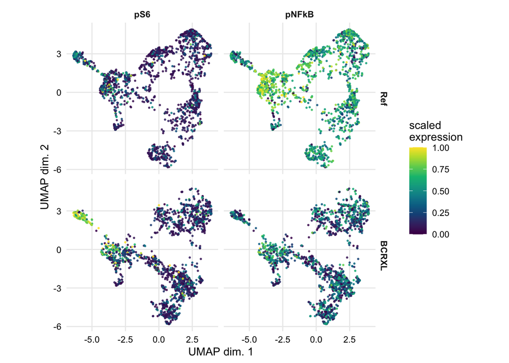

```r
# color by marker expression & split by condition
plotDR(sce,
    facet_by = "condition",
    color_by = c("pS6", "pNFkB"))
```

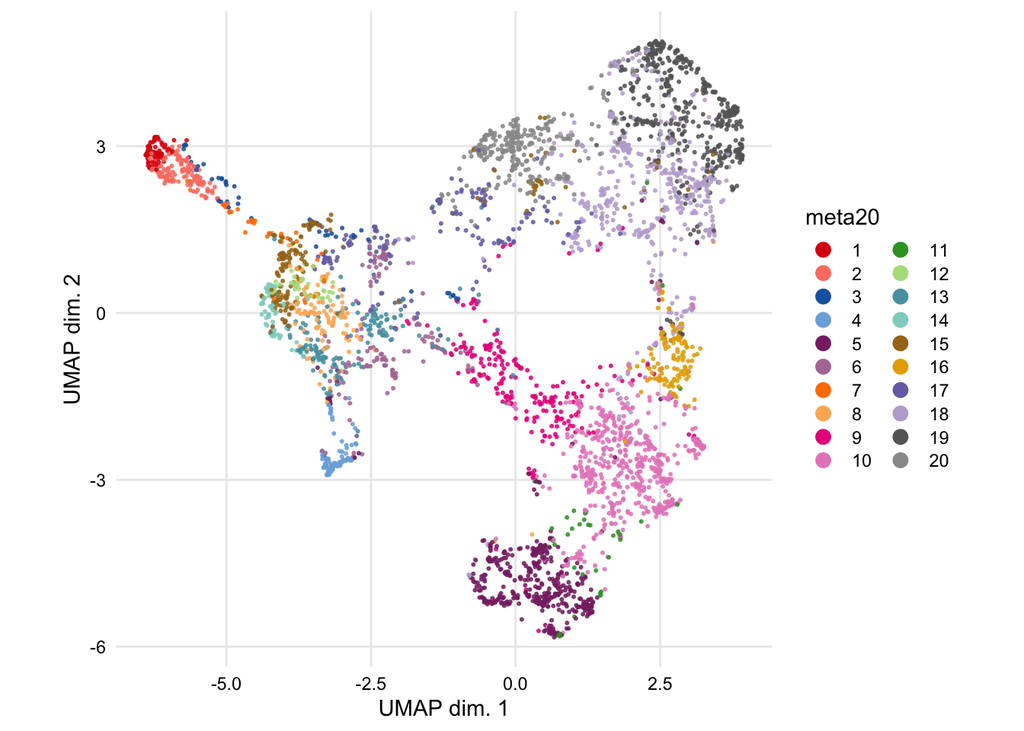

```r
plotDR(sce, color_by = "meta20")
```

# Differental testing with `diffcyt`

*CATALYST* has been designed to be compatible with the *diffcyt* package (Weber et al. 2019), which implements statistical methods for differential discovery in high-dimensional cytometry (including flow cytometry, mass cytometry or CyTOF, and oligonucleotide-tagged cytometry) using high-resolution clustering and moderated tests.

Please refer to the *diffcyt* [vignette](https://bioconductor.org/packages/3.7/bioc/vignettes/diffcyt/inst/doc/diffcyt_workflow.html) and R documentation (`??diffcyt`) for more detailed information.

```r
# create design & contrast matrix
design <- createDesignMatrix(
    experiment_info = ei(sce),
    cols_design = "condition")
contrast <- createContrast(c(0, 1))

# if including 'patient_id' in the design:
#contrast <- createContrast(c(0, 1, rep(0, 8)))

# test for
# - differential states (DS) within clusters
# - differential abundance (DA) of clusters
res_DS <- diffcyt(sce,
    design = design,
    contrast = contrast,
    analysis_type = "DS",
    method_DS = "diffcyt-DS-limma",
    clustering_to_use = "meta10")

res_DA <- diffcyt(sce,
    design = design,
    contrast = contrast,
    analysis_type = "DA",
    method_DA = "diffcyt-DA-edgeR",
    clustering_to_use = "meta10")

# extract result tables
tbl_DA <- rowData(res_DA$res)
tbl_DS <- rowData(res_DS$res)
```

## `plotDiffHeatmap`: Heatmap of differential testing results

Differential testing results returned by *diffcyt* can be displayed with the `plotDiffHeatmap` function.

For differential abundance (DA) tests, `plotDiffHeatmap` will display relative cluster abundances by samples; for differential state (DS) tests, `plotDiffHeatmap` will display aggregated marker expressions by sample.

## Ex. 1: DA testing results

We here set `all = TRUE` to display top-20 DA analysis results, without filtering on adjusted p-values and logFCs. Since differential testing was performed on 10 clusters only, this will simply include all available results.  
By setting `fdr = 0.05` despite not filtering on significance, we can control the right-hand side annotation:

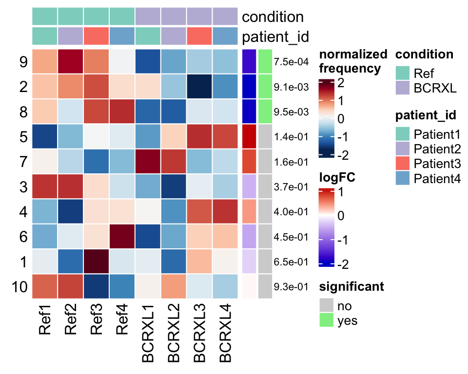

```r
plotDiffHeatmap(sce, tbl_DA, all = TRUE, fdr = 0.05)
```

## Ex. 2: DS testing results

Via setting `fdr = 0.05`, we here display the top DS analysis results in terms of significance. Alternative to the example above, we sort these according their logFCs (`sort_by = "lfc"`), and include only a selected sample annotation (`col_anno = "condition"`):

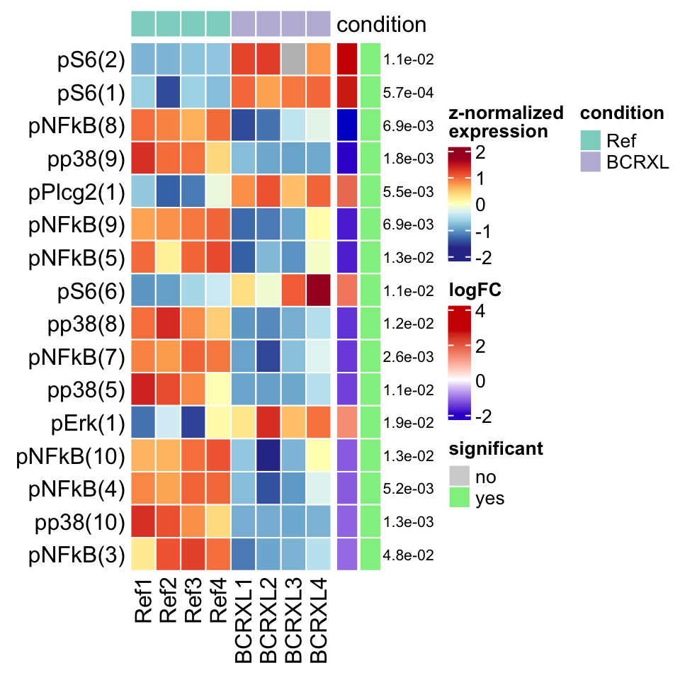

```r
plotDiffHeatmap(sce, tbl_DS, fdr = 0.05,
    sort_by = "lfc", col_anno = "condition")
```

## References

Bodenmiller, Bernd, Eli R Zunder, Rachel Finck, Tiffany J Chen, Erica S Savig, Robert V Bruggner, Erin F Simonds, et al. 2012. “Multiplexed Mass Cytometry Profiling of Cellular States Perturbed by Small-Molecule Regulators.” *Nature Biotechnology* 30 (9): 858–67.

Monti, Stefano, Pablo Tamayo, Jill Mesirov, and Todd Golub. 2003. “Consensus Clustering: A Resampling-Based Method for Class Discovery and Visualization of Gene Expression Microarray Data.” *Machine Learning* 52 (1): 91–118.

Nowicka, Malgorzata, Carsten Krieg, Helena L Crowell, Lukas M Weber, Felix J Hartmann, Silvia Guglietta, Burkhard Becher, Mitchell P Levesque, and Mark D Robinson. 2019. “CyTOF Workflow: Differential Discovery in High-Throughput High-Dimensional Cytometry Datasets.” *F1000Research* 6: 748.

Weber, Lukas M, Malgorzata Nowicka, Charlotte Soneson, and Mark D Robinson. 2019. “Diffcyt: Differential Discovery in High-Dimensional Cytometry via High-Resolution Clustering.” *Communications Biology* 2: 183.